# Filter RD7 Essential scUTRquant Data

Mervin M Fansler

18 November 2022

# Purpose

Counts from scUTRquant include all cells passing the UMI threshold. We will filter to only those cells annotated in the published data.

# Initialization

## Libraries

```r
library(magrittr)
library(SingleCellExperiment)
library(tidyverse)
```

## Parameters

```r
set.seed(20210818)
FILE_SCE_TX="data/sce/rd7_essential.txs.Rds"
#FILE_SCE_GENE="data/sce/rd7_essential.genes.Rds"
CSV_CELL_ANNOTS="metadata/rd7-essential-cell-annots.csv.gz"

OUT_SCE_TX="data/sce/rd7_essential.annot.txs.Rds"
#OUT_SCE_GENE="data/sce/rd7_essential.annot.genes.Rds"
```

# Data

## Transcripts

```r
sce_txs <- readRDS(FILE_SCE_TX)

## cell annots
df_cells <- read_csv(CSV_CELL_ANNOTS)

bxs_annots <- mutate(df_cells, bx=str_extract(cell_id, "[ACGT]{16}$")) %>%
    dplyr::select(sample_id, bx) %>%
    group_by(sample_id) %>%
    summarize(bx=list(bx)) %>%
    deframe()

bxs_cells <- colData(sce_txs) %>%
    as_tibble %>%
    mutate(bx=str_extract(cell_id, "[ACGT]{16}$")) %>%
    dplyr::rename(sample_id=sample_id.x) %>%
    group_by(sample_id) %>%
    summarize(bx=list(bx)) %>%
    deframe()
```

# Data Checking

## Annotated Cells

We should have ~250K annotated cells.

```r
sum(!is.na(sce_txs$gem_group))
```

```
## [1] 671
```

This looks like something is wrong in the annotation.

## Barcode Overlap Fractions

For each sample in the annotation and in the cells, count the fraction of annotated barcodes that are detected among the cells. It should be that, e.g., `RD7_01` should have highest fraction with the `RD7_01` sample.

We will plot this and expect a diagonal matrix.

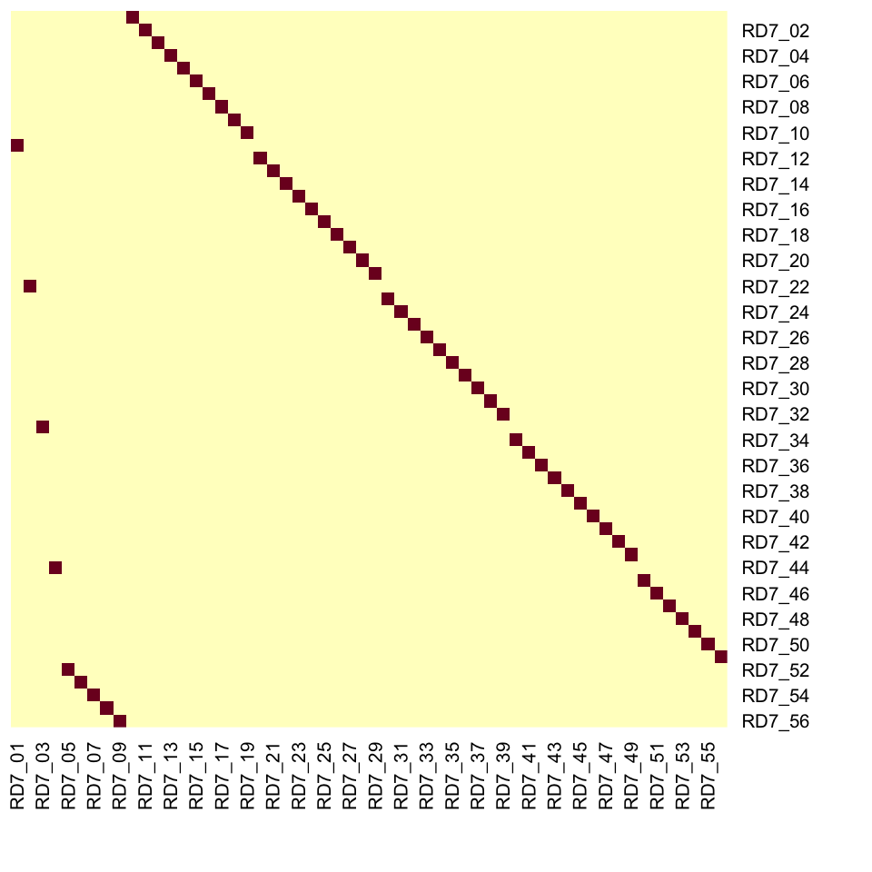

```r
samples_annots = names(bxs_annots)
samples_cells = names(bxs_cells)
bx_frac <- matrix(nrow=length(samples_annots), ncol=length(samples_cells),
                  dimnames=list(sample_annots=samples_annots,
                                sample_cells=samples_cells))

for (i in samples_annots) {
    for (j in samples_cells) {
        bx_frac[i,j] <- mean(bxs_annots[[i]] %in% bxs_cells[[j]])
    }
}

heatmap(bx_frac[seq(56,1),], Rowv=NA, Colv=NA)
```

This indicates that the sample names given to the BAMs do not match those used in the annotation table. This could be a mistake in our data processing. For now, since the samples appear to match one-to-one, we can try mapping the names and check if the downstream analysis passes some positive controls (e.g., knock-down of target gene expression).

# Repair Cell Annotations

```r
df_sample_map <- which(bx_frac > 0.99, arr.ind=TRUE, useNames=TRUE) %>%
    as_tibble() %>%
    mutate(across(everything(), ~ sprintf("RD7_%02d", .x))) %>%
    dplyr::rename(sample_id=sample_annots, sample_id_old=sample_cells)

map_cell_id <- colData(sce_txs) %>%
    as_tibble() %>%
    dplyr::select(cell_id, sample_id.x) %>%
    dplyr::rename(sample_id_old=sample_id.x, cell_id_old=cell_id) %>%
    left_join(df_sample_map, by="sample_id_old") %>%
    mutate(bx=str_extract(cell_id_old, "[ACGT]{16}$"),
           cell_id=str_c(sample_id, bx, sep="_")) %>%
    dplyr::select(cell_id_old, cell_id) %>%
    deframe()
```

Are all names cell_ids mappable? TRUE

How many cells would then be annotated? 247913

These look good, so we apply this mapping.

```r
colnames(sce_txs) %<>% { map_cell_id[.] }
sce_txs %<>% `[`(,colnames(sce_txs) %in% df_cells$cell_id)


colData(sce_txs) <- df_cells %>%
    DataFrame(row.names=.$cell_id) %>%
    `[`(colnames(sce_txs),)

gc()
```

```
##              used   (Mb) gc trigger    (Mb) limit (Mb)   max used    (Mb)
## Ncells    8106014  433.0   16009600   855.1         NA   10523067   562.0
## Vcells 1204364232 9188.6 3853480852 29399.8     262144 4017193628 30648.8
```

## Check UMI Counts

For sanity check, we can compare the total UMI counts from the cell data with that found in the annotations. We expect a diagonal; complete failure would look like a random distribution.

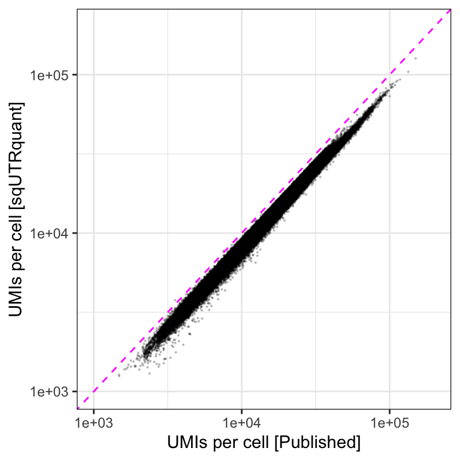

```r
colData(sce_txs) %>%
    as_tibble() %>%
    mutate(umi_count_sq=colSums(counts(sce_txs))) %>%
    ggplot(aes(x=UMI_count, y=umi_count_sq)) +
    geom_point(size=0.1, alpha=0.2) +
    geom_abline(linetype='dashed', color='magenta') +
    scale_x_log10(limits=c(1e3,2e5)) + scale_y_log10(limits=c(1e3,2e5)) +
    labs(x="UMIs per cell [Published]", y="UMIs per cell [sqUTRquant]") +
    theme_bw()
```

While it looks like we have undercounting, the trend of the data appears consistent with the cells having the correct annotation.

### Export

```r
saveRDS(sce_txs, OUT_SCE_TX)
```

# Runtime Details

## Conda Environment

[output not shown]

[output cut: 174 more lines]

[output not shown]